# IODS course project

## Multiple regression

Multiple regression is conducted when there are more than one explanatory variables in a model. The above situation where each variable was fitted into the simple linear regression to estimate their individual effect on the dependent variable can be made analysis can be simplified by conducting a multiple regression analysis

```r
# We would like to run a multiple regression with this code
model2 <- lm(points ~ attitude + stra + surf, data = learning2014)

# Let us print the summary of our multiple regression
summary(model2)
```

```
##
## Call:
## lm(formula = points ~ attitude + stra + surf, data = learning2014)
##
## Residuals:
##      Min       1Q   Median       3Q      Max
## -17.1550  -3.4346   0.5156   3.6401  10.8952
##
## Coefficients:
##             Estimate Std. Error t value Pr(>|t|)
## (Intercept)  11.0171     3.6837   2.991  0.00322 **
## attitude      3.3952     0.5741   5.913 1.93e-08 ***
## stra          0.8531     0.5416   1.575  0.11716
## surf         -0.5861     0.8014  -0.731  0.46563
## ---
## Signif. codes:  0 '***' 0.001 '**' 0.01 '*' 0.05 '.' 0.1 ' ' 1
##
## Residual standard error: 5.296 on 162 degrees of freedom
## Multiple R-squared:  0.2074, Adjusted R-squared:  0.1927
## F-statistic: 14.13 on 3 and 162 DF,  p-value: 3.156e-08
```

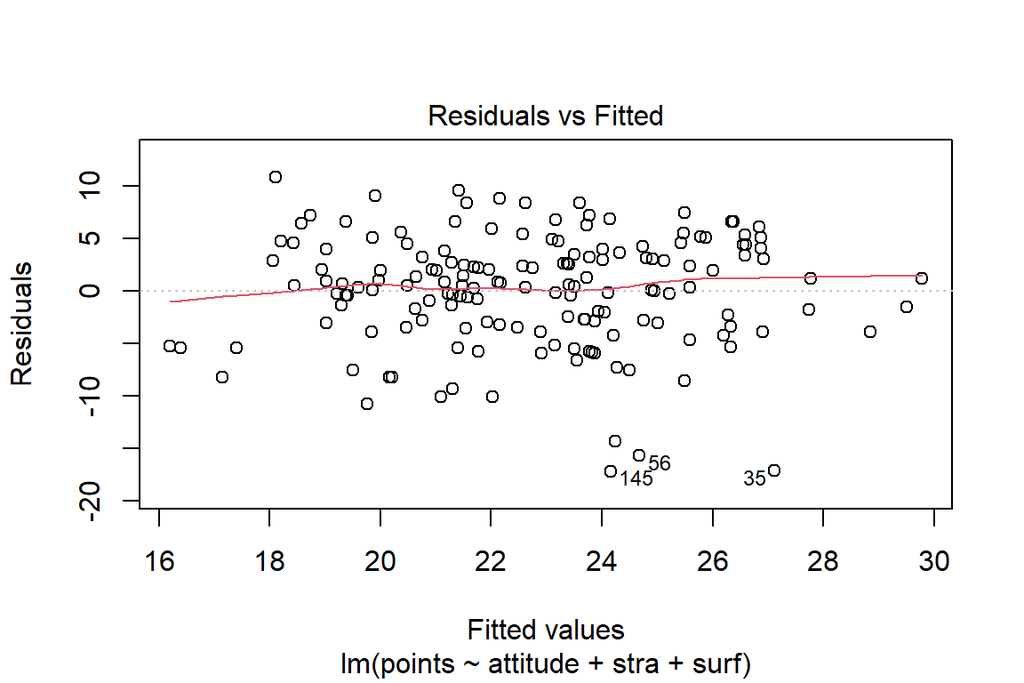

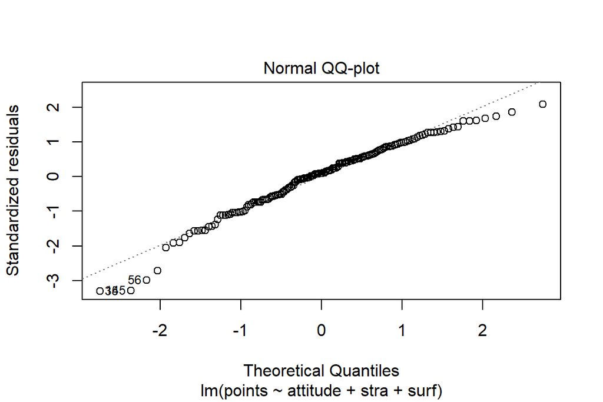

[figure not shown]

```r
# Here we want to draw the diagnostic plots using the plot() function.
plot(model2, which = c(1,2,3), caption = list("Residuals vs Fitted", "Normal QQ-plot", "Residuals vs Leverage"))
```

#### Explanation of the diagnostic plots

1. For the QQ plot, the normality assumption shows reasonable fit to the line implying that the errors of the model are normally distributed.

2.For the Residual VS Fitted plot shows that as the fitted values increases, the scattered plot deviates from the line.

# Logical regression analysis of the IODS project

*This section describes the steps taken to perform logical regression analysis of data obtained for the Machine Learning repository*

First, let me begin by reading the data for this analysis into R from online.

```r
# install.packages("ggplot2")
#library(ggplot2)

# Reading the data from web address
data <- "https://github.com/rsund/IODS-project/raw/master/data/alc.csv"

# read the math class questionaire data into memory
math_por <- read.table(data, sep = "," , header=TRUE)

# We can have glimpse of the data
str(math_por)
```

```
## 'data.frame':    370 obs. of  51 variables:
##  $ school    : chr  "GP" "GP" "GP" "GP" ...
##  $ sex       : chr  "F" "F" "F" "F" ...
##  $ age       : int  15 15 15 15 15 15 15 15 15 15 ...
##  $ address   : chr  "R" "R" "R" "R" ...
##  $ famsize   : chr  "GT3" "GT3" "GT3" "GT3" ...
##  $ Pstatus   : chr  "T" "T" "T" "T" ...
##  $ Medu      : int  1 1 2 2 3 3 3 2 3 3 ...
##  $ Fedu      : int  1 1 2 4 3 4 4 2 1 3 ...
##  $ Mjob      : chr  "at_home" "other" "at_home" "services" ...
##  $ Fjob      : chr  "other" "other" "other" "health" ...
##  $ reason    : chr  "home" "reputation" "reputation" "course" ...
##  $ guardian  : chr  "mother" "mother" "mother" "mother" ...
##  $ traveltime: int  2 1 1 1 2 1 2 2 2 1 ...
##  $ studytime : int  4 2 1 3 3 3 3 2 4 4 ...
```

[output cut: 37 more lines]

```r
dim(math_por)
```

```
## [1] 370  51
```

```r
colnames(math_por)
```

```
##  [1] "school"     "sex"        "age"        "address"    "famsize"
##  [6] "Pstatus"    "Medu"       "Fedu"       "Mjob"       "Fjob"
## [11] "reason"     "guardian"   "traveltime" "studytime"  "schoolsup"
## [16] "famsup"     "activities" "nursery"    "higher"     "internet"
## [21] "romantic"   "famrel"     "freetime"   "goout"      "Dalc"
## [26] "Walc"       "health"     "n"          "id.p"       "id.m"
## [31] "failures"   "paid"       "absences"   "G1"         "G2"
## [36] "G3"         "failures.p" "paid.p"     "absences.p" "G1.p"
## [41] "G2.p"       "G3.p"       "failures.m" "paid.m"     "absences.m"
## [46] "G1.m"       "G2.m"       "G3.m"       "alc_use"    "high_use"
## [51] "cid"
```

The data contain 370 observations and 51 variables. The data was read from the online ML repository, which is a combined students data from the UCI.

```r
# Let me print the heading to see the nature of the data

head(math_por)
```

```
##   school sex age address famsize Pstatus Medu Fedu     Mjob     Fjob     reason
## 1     GP   F  15       R     GT3       T    1    1  at_home    other       home
## 2     GP   F  15       R     GT3       T    1    1    other    other reputation
## 3     GP   F  15       R     GT3       T    2    2  at_home    other reputation
## 4     GP   F  15       R     GT3       T    2    4 services   health     course
## 5     GP   F  15       R     GT3       T    3    3 services services reputation
## 6     GP   F  15       R     GT3       T    3    4 services   health     course
##   guardian traveltime studytime schoolsup famsup activities nursery higher
## 1   mother          2         4       yes    yes        yes     yes    yes
## 2   mother          1         2       yes    yes         no      no    yes
## 3   mother          1         1       yes    yes        yes     yes    yes
## 4   mother          1         3       yes    yes        yes     yes    yes
## 5    other          2         3        no    yes        yes     yes    yes
## 6   mother          1         3       yes    yes        yes     yes    yes
##   internet romantic famrel freetime goout Dalc Walc health n id.p id.m failures
```

[output cut: 20 more lines]

We observe that some new variables different from the original data collected in the separate datasets were added to the combined data. These new variables shows a suffix “.p” or “.m” indicating “por_data” and “math_data” respectively. For example, the “id.p” and “id.m”

#### Variables selected to conducted anaylsis

I am selecting the following variables: 1. Sex 2. high_use 2. G3 (students final grade) 3. famrel (students quality of family relationship)

Based on my variable selection, the following are my hypothesis:

**H1** There is a significant difference of alcohol consuption in male and females.

**H2** Alcohol consumption can affect the quality of students’ family relationship.

**H3** Alcohol consumption can have a significant impact of on students’ final grades.

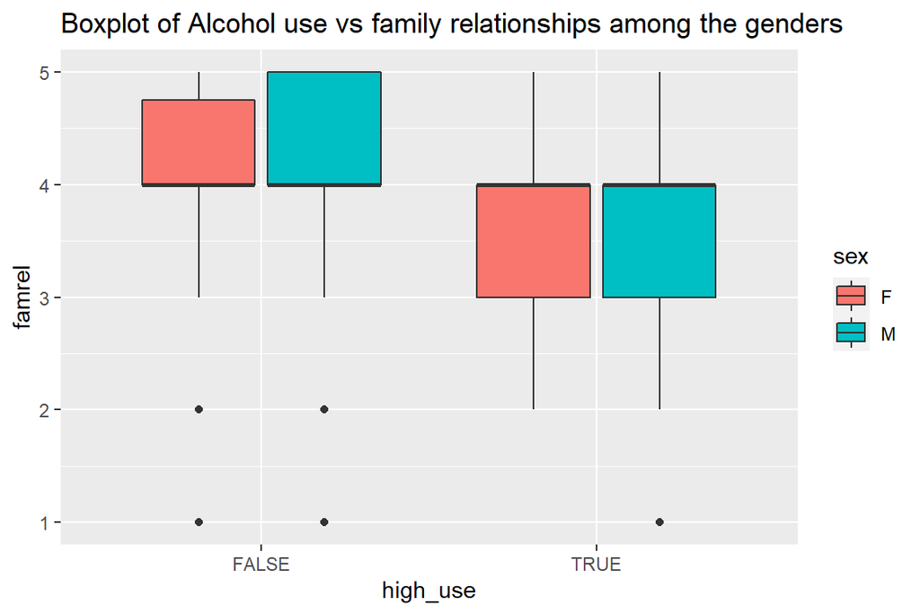

```r
#This section, I am going to be explore my four variables by plotting graphs.
library(dplyr)
library(ggplot2)
ggplot(data=math_por, aes(x=high_use, y=famrel, fill=sex))+ geom_boxplot() +
  labs(title="Boxplot of Alcohol use vs family relationships among the genders")
```

*Figure 1*

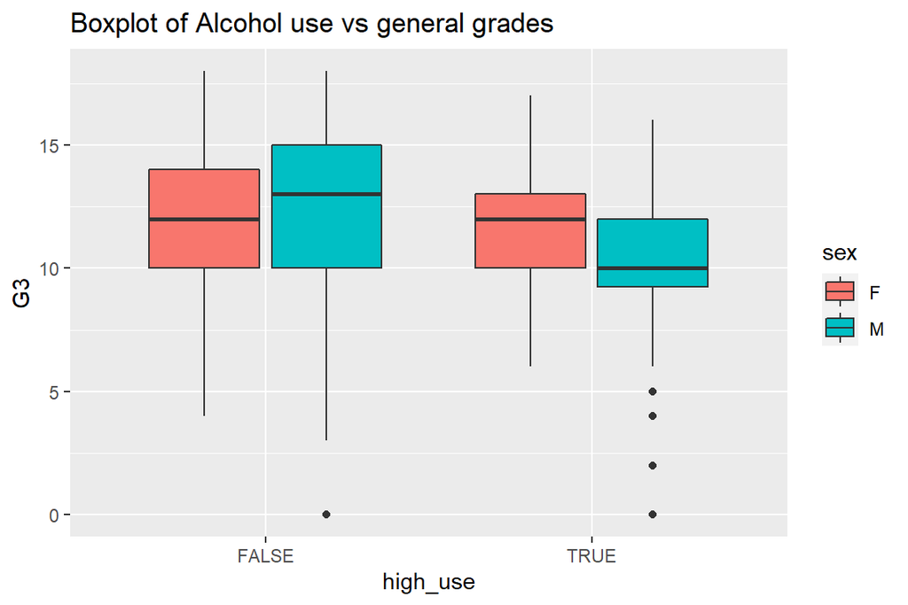

```r
# Here, I am trying to plot the graph of high_use of alcohol against sex and grades
ggplot(data=math_por, aes(x=high_use, y=G3, fill=sex))+ geom_boxplot() +
  labs(title="Boxplot of Alcohol use vs general grades")
```

*Figure 2*

### Logistics regression analysis here!

```r
# find the model with glm() with variables alcohol use vs students' grades, family relationship, and sex
m <- glm(high_use ~ G3 + famrel + sex, data = math_por, family = "binomial")

# Summary of the model is printed below
m
```

```
##
## Call:  glm(formula = high_use ~ G3 + famrel + sex, family = "binomial",
##     data = math_por)
##
## Coefficients:
## (Intercept)           G3       famrel         sexM
##     0.89134     -0.08851     -0.32041      0.98858
##
## Degrees of Freedom: 369 Total (i.e. Null);  366 Residual
## Null Deviance:       452
## Residual Deviance: 423.1     AIC: 431.1
```

```r
#Coefficient of the model is printed here
coef(m)
```

```
## (Intercept)          G3      famrel        sexM
##  0.89133738 -0.08851078 -0.32040808  0.98858435
```